# YAPS - Yet Another Positioning Solver

OTN Telemetry Workshop Series, Dalhousie University, Halifax, Canada Part 3 - Danish pike in a large lake

Henrik Baktoft

Technical University of Denmark (DTU)  
hba@aqua.dtu.dk

Feb 19, 2020

# Setup and needed libraries

Set timezone to UTC and load needed libraries

```r
rm(list=ls())
Sys.setenv(TZ='UTC')
library(data.table)
library(leaflet)
library(sp)
library(lubridate)
library(ggplot2)
library(caTools)
library(viridis)
library(yaps)
source('../yaps_OTN_helperFuncs.R')
```

# Description

These data are included in the `yaps` package (run `?hald` for info). Data were collected as part of a larger study including brown trout (smolt and adult), pike and eel in the Danish lake Hald. Lake Hald is large and deep (by Danish standards; 3.42 km<sup>2</sup>; max depth 34 m), so depth is relevant in order to get best possible track estimation. A total of 70 hydrophones (Thelma TBR700) were deployed to cover the entire lake. The data set contains a single week of detections including a single tow track and tracks of a few pike (*Esox lucius*).

This example focus on:

- Tag 5138: tow track, fixed BI (10 s), **gps data available**
- Tag 1335: pike, random BI (10-30 s), **known sequence**
- Tag 1315: pike, random BI (60-120 s), **known sequence**

An appropiate sync_model is included in the package and will be used for this demonstration to save time. Code to obtain this sync_model can be found in the appendix below.

## A look at the data

Notice the object `burst_seqs` - these are vectors of intervals between consequtive pings from the two transmitters included in this example data. Not all manufacturers are willing to provide these data to their users even though it is just a stream of random numbers - luckily Thelma Biotel are.  
`data.table`s `hydros` and `detections` are as usual.  
The object `sync_model` contains the already optimized synchronization model applicable for these data.

```r
names(hald)
```

```
[1] "hydros"     "detections" "sync_model" "fish"       "burst_seqs"
```

```r
hydros <- hald$hydros
detections <- hald$detections
sync_model <- hald$sync_model
str(hald$burst_seqs)
```

```
List of 2
 $ seq1315: int [1:60290] 73 106 110 102 113 89 65 115 103 114 ...
 $ seq1335: int [1:270460] 14 22 29 18 25 10 24 14 28 15 ...
```

## The study site

Study site geometry is rather complex. (Code to make the map is in the .Rmd file).  
Note, how a sequential synchronization process in this case could lead to error propagation. Also note, there are lots of impossible sync tag - hydro combinations.

[interactive chart not shown]

## A look at the sync model

There might be room for improvement, but it will suffice for now. Additionally, the hope for this study was not to achieve sub-meter accuracy and precision given the large extent of the study area.

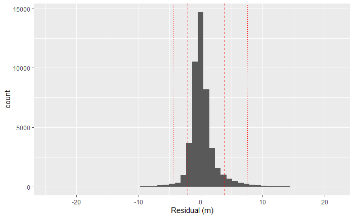

```r
plotSyncModelResids(sync_model, by='overall')
```

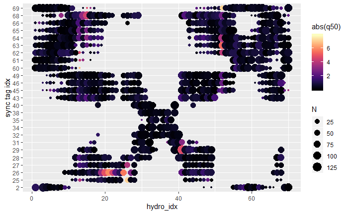

```r
plotSyncModelResids(sync_model, by='quantiles')
```

```r
# plotSyncModelResids(sync_model, by='sync_tag')
# plotSyncModelResids(sync_model, by='hydro')
```

As part of fitting the synchronization model, we estimated positions of two hydros as their gps-obtained positions were unceratin. We will use these estimated positions for the track estimation.

```r
which(sync_model$inp_synced$dat_tmb_sync$fixed_hydros_vec !=1)
```

```
[1] 32 70
```

```r
hydros_yaps <- data.table::data.table(sync_model$pl$TRUE_H)
colnames(hydros_yaps) <- c('hx','hy','hz')

cbind(hydros[c(32, 70), c('x','y')], hydros_yaps[c(32,70), c('hx','hy')])
```

| x | y | hx | hy |
| --- | --- | --- | --- |
| 521113.0 | 6249339 | 521128.1 | 6249343 |
| 520762.6 | 6247409 | 520762.2 | 6247410 |

## Applying the sync model to all detections

This is easily done, since we already have the sync_model

```r
detections_synced <- applySync(toa=detections, hydros=hydros, sync_model=sync_model)
```

# Estimating tracks using `yaps`

## Tag 5138 - tow track - **fixed** burst interval

### Compiling the data

Remember this is a fixed burst interval transmitter (BI = 10 s).

Let’s have a look at the data. Note, this plot only makes sense for transmitters where the burst interval is set at whole seconds (random or not).

```r
dat_tow <- detections_synced[tag==5138]
gps <- fread("../data/hald_gps_test_track.csv")

with(dat_tow, table(hydro_idx))
```

```
hydro_idx
  1   2   3   4   5   6   7   8   9  53  54  55  56  57  58  59  60  61  62  63  64  69  70
121 241 277 404 420 394 400 242   9  28  73 287 399 402 318  54 206 419 401 202   4 417 409
```

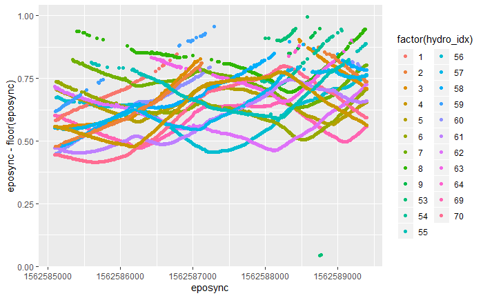

```r
ggplot(data=dat_tow) + geom_point(aes(x=eposync, y=eposync-floor(eposync), col=factor(hydro_idx)))
```

Get TOA matrix for YAPS and have a look

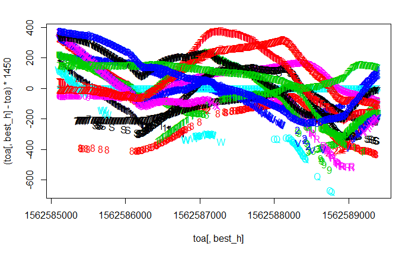

```r
toa_tow <- getToaYaps(synced_dat=dat_tow, hydros=hydros, rbi_min=10, rbi_max=10)
plotToa(toa_tow)
```

```r
plotNobs(toa_tow)
```

### Get `inp` and run YAPS

```r
inp_tow <- getInp(toa=toa_tow, hydros=hydros_yaps, E_dist="t", n_ss=5, pingType="sbi", sdInits=1, ss_data_what="est", ss_data=0, biTable=NULL)
yaps_tow <- runYaps(inp_tow, maxIter=500, getPlsd=TRUE, getRep=TRUE, silent=TRUE)
```

```
[1] "Running yaps..."
[1] "...yaps converged (obj: -31872.4971849078)"
```

### Results

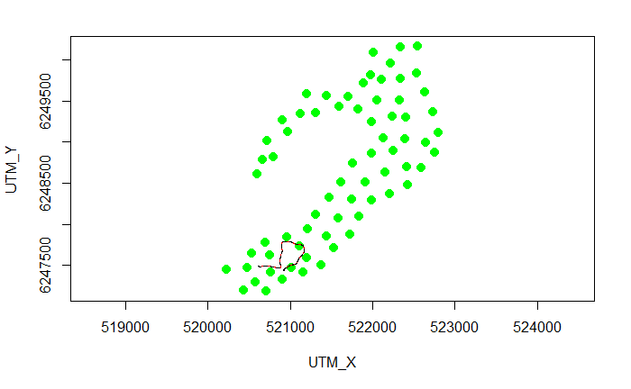

```r
plotYaps(inp_tow, yaps_tow)
lines(Y~X, data=gps, lty=2)
```

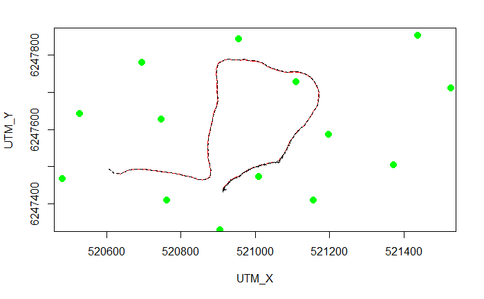

```r
# zoom in
plotYaps(inp_tow, yaps_tow, xlim=c(520500, 521500), ylim=c(6247400, 6247800))
lines(Y~X, data=gps, lty=2)
```

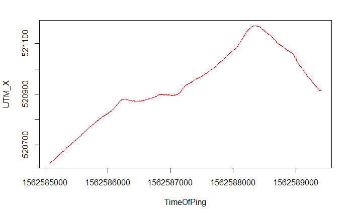

```r
plotYaps(inp_tow, yaps_tow, type="coord_X")
```

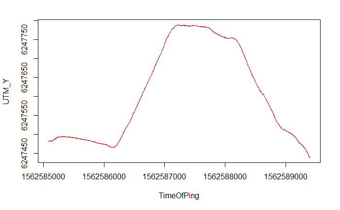

```r
plotYaps(inp_tow, yaps_tow, type="coord_Y")
```

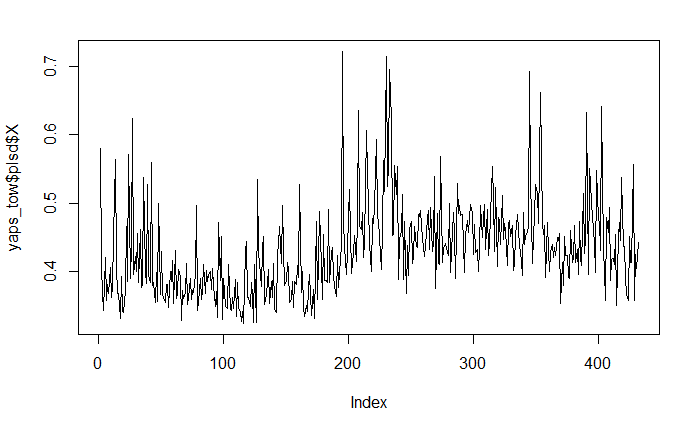

```r
# standard error of position estimates are hardly visible
plot(yaps_tow$plsd$X, type="l")
```

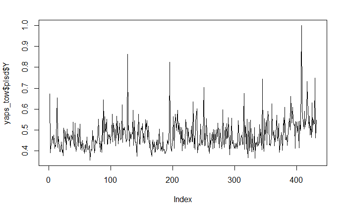

```r
plot(yaps_tow$plsd$Y, type="l")
```

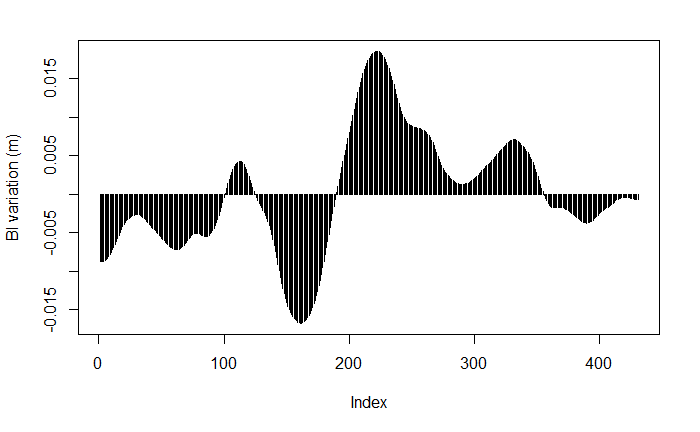

```r
# Fixed burst interval - how fixed? Note y-axis is in meter
bi <- diff(yaps_tow$pl$top)
plot((bi - mean(bi)) * 1460, ylab="BI variation (m)", type="h")
```

```r
# estimated speed of sound - sanity check
yaps_tow$pl$ss
```

```
[1] 1465.509 1464.426 1463.435 1464.299 1465.580
```

```r
getSS(temp=c(15, 16, 17))
```

```
[1] 1464.915 1467.978 1470.967
```

```
default 'pch' is smaller than number of columns and hence recycled
```

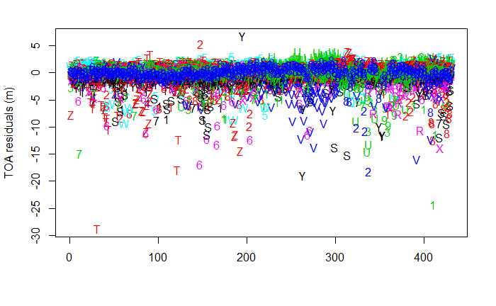

```r
# look at the residual
matplot(t((yaps_tow$rep$mu_toa - inp_tow$datTmb$toa))*1460, ylab="TOA residuals (m)")
```

### Tag 5138 tow track - downsampling max_hydro <- 3

Looks good, but this data set is highly saturated! To showcase the benefit of fixed burst interval, we downsample and re-run `yaps`

```r
plotNobs(toa_tow)
```

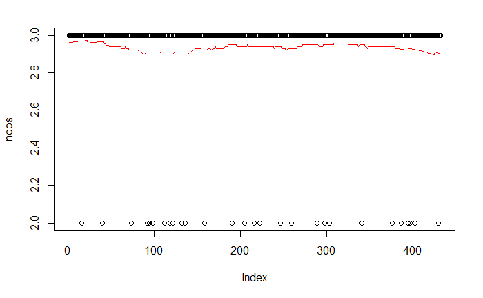

```r
max_hydro <- 3
toa_tow3<- downSampleToa(toa_tow, max_hydro)
```

```r
inp_tow3 <- getInp(toa=toa_tow3, hydros=hydros_yaps, E_dist="t", n_ss=5, pingType="sbi", sdInits=1, ss_data_what="est", ss_data=0, biTable=NULL)
yaps_tow3 <- runYaps(inp_tow3, maxIter=500, getPlsd=TRUE, getRep=TRUE, silent=TRUE)
```

```
[1] "Running yaps..."
[1] "...yaps converged (obj: -5993.4922707068)"
```

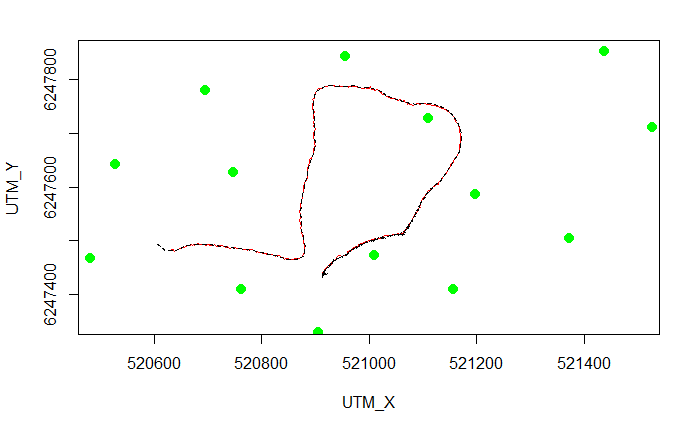

```r
plotYaps(inp_tow3, yaps_tow3, xlim=c(520500, 521500), ylim=c(6247400, 6247800))
lines(Y~X, data=gps, lty=2)
```

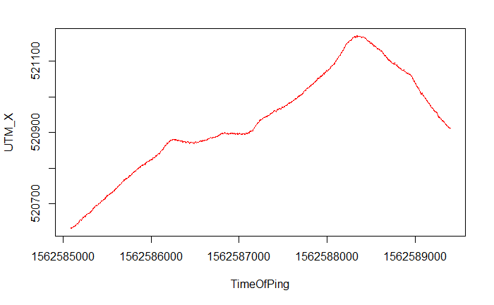

```r
plotYaps(inp_tow3, yaps_tow3, type="coord_X")
```

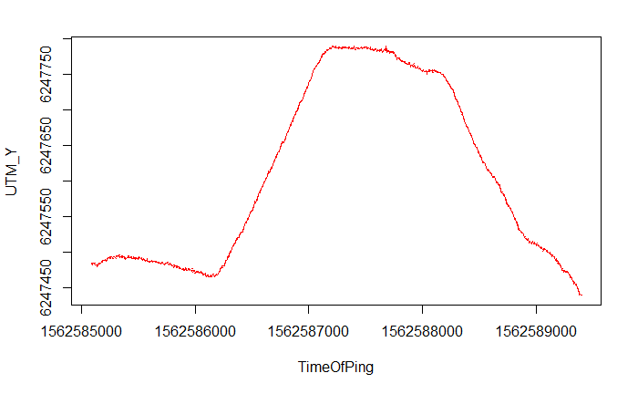

```r
plotYaps(inp_tow3, yaps_tow3, type="coord_Y")
```

### Tag 5138 tow track - downsampling max_hydro <- 1

For fixed burst interval transmitters, we can go really low on detections.

```r
plotNobs(toa_tow)
```

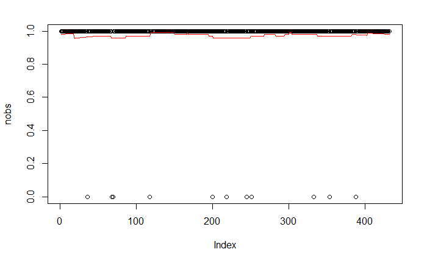

```r
max_hydro <- 1
toa_tow1<- downSampleToa(toa_tow, max_hydro)
```

```r
inp_tow1 <- getInp(toa=toa_tow1, hydros=hydros_yaps, E_dist="t", n_ss=5, pingType="sbi", sdInits=1, ss_data_what="est", ss_data=0, biTable=NULL)
yaps_tow1 <- runYaps(inp_tow1, maxIter=500, getPlsd=TRUE, getRep=TRUE, silent=TRUE)
```

```
[1] "Running yaps..."
[1] "...yaps converged (obj: -1609.37815100249)"
```

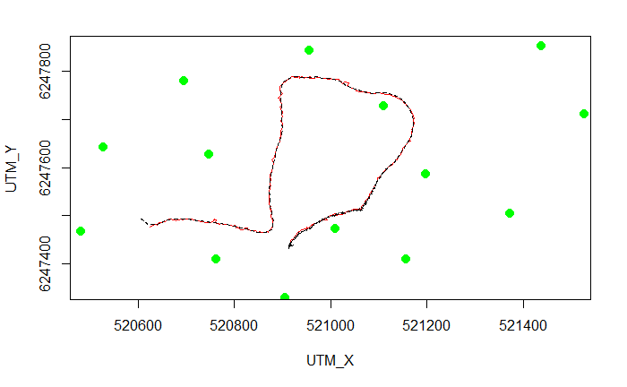

```r
plotYaps(inp_tow1, yaps_tow1, xlim=c(520500, 521500), ylim=c(6247400, 6247800))
lines(Y~X, data=gps, lty=2)
```

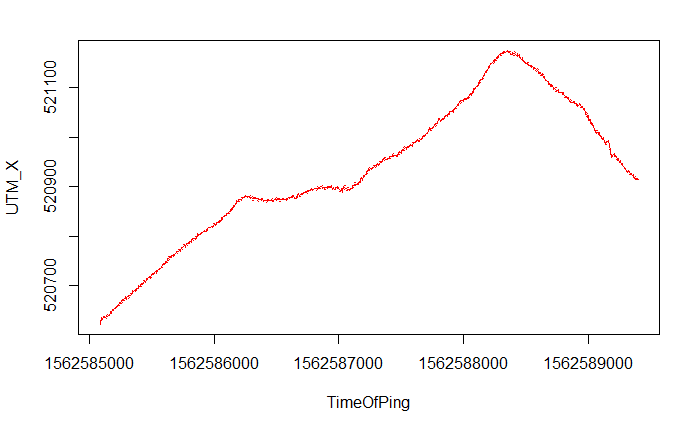

```r
plotYaps(inp_tow1, yaps_tow1, type="coord_X")
```

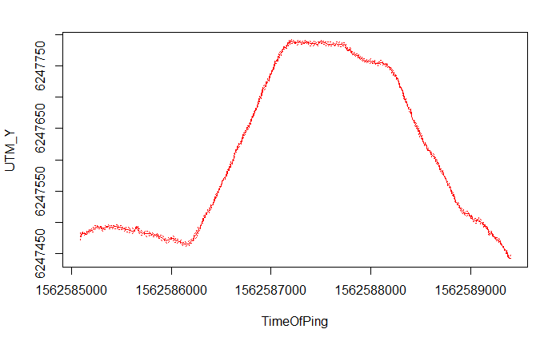

```r
plotYaps(inp_tow1, yaps_tow1, type="coord_Y")
```

### Comparing standard errors of position estimates

```r
par(mfrow=c(2,2))
plotYaps(inp_tow, yaps_tow, type="coord_X", main="X all data")
plotYaps(inp_tow, yaps_tow, type="coord_Y", main="Y all data")
```

```r
plotYaps(inp_tow1, yaps_tow1, type="coord_X", main="X max_hydro=1")
plotYaps(inp_tow1, yaps_tow1, type="coord_Y", main="Y max_hydro=1")
```

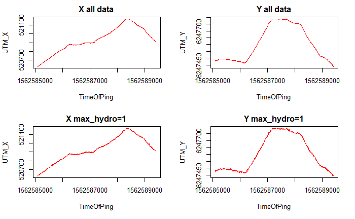

```r
par(mfrow=c(1,1))

par(mfrow=c(3,1))
```

```r
ylim <- c(0, 5)
plot(yaps_tow$plsd$X,  type="h", ylim=ylim, main="Full")
plot(yaps_tow3$plsd$X, type="h", ylim=ylim, main="max_hydro=3")
```

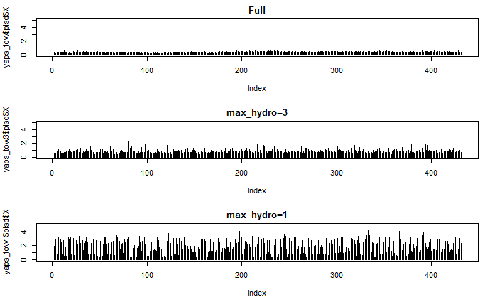

```r
plot(yaps_tow1$plsd$X, type="h", ylim=ylim, main="max_hydro=1")
par(mfrow=c(1,1))
```

### Note on the downsampling

One reason we can estimate a decent track even with max_hydro = 1 is, that multiple hydrophones are detecting the signals. It will, of course, not work if there only was a single hydrophone in the water.

## Tag 1335 - pike - random BI sequence - assuming **secret** sequence

Remember this transmitter is a random burst interval (BI 10 - 30 s), but we know the burst sequence. However, first we assume, we don’t and treat it like a random BI trasnmitter with secret burst sequence. ### Compiling the data

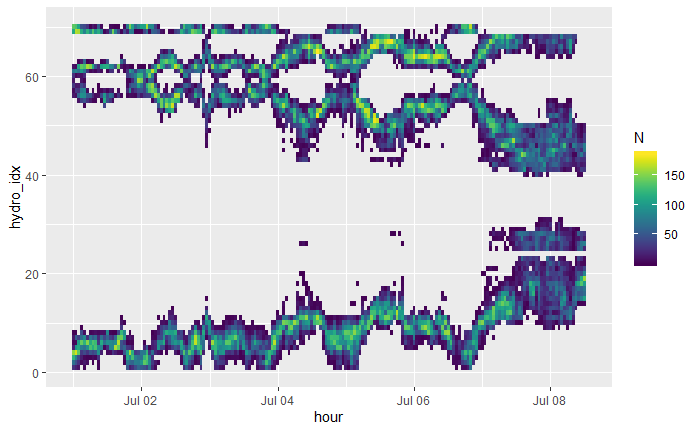

```r
dat1335 <- detections_synced[tag==1335]
ping_type <- 'rbi'
rbi_min <- 10
rbi_max <- 30

# get number of detections per hydro per hour
dat1335[, hour := floor_date(ts, unit="hour")]
summ <- dat1335[, .N, by=c('hydro_idx', 'hour')]
ggplot(data=summ) + geom_tile(aes(x=hour, y=hydro_idx, fill=N)) + scale_fill_viridis()
```

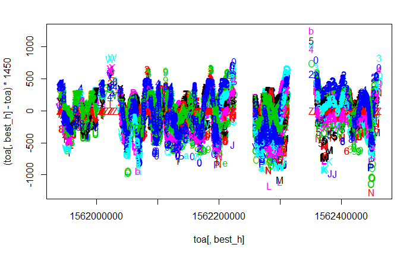

```r
# Get TOA matrix for YAPS
toa1335_rbi <- getToaYaps(synced_dat=dat1335, hydros=hydros_yaps, rbi_min=rbi_min, rbi_max=rbi_max)

# Have a look at the raw data...
plotToa(toa1335_rbi)
```

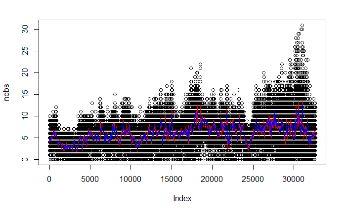

```r
plotNobs(toa1335_rbi)
```

More than 30.000 pings will take pretty long time to process, so we use a small a subset of the data.

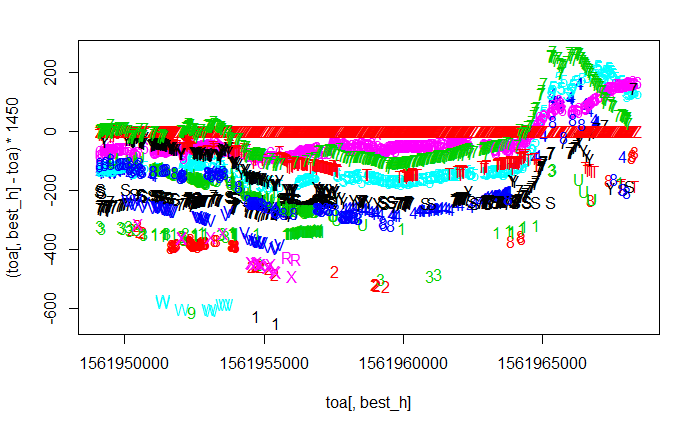

```r
ping_1 <- 501
n_ping <- 1000
toa1335_rbi_yaps <- toa1335_rbi[ping_1:(ping_1 + n_ping - 1), ]
plotToa(toa1335_rbi_yaps)
```

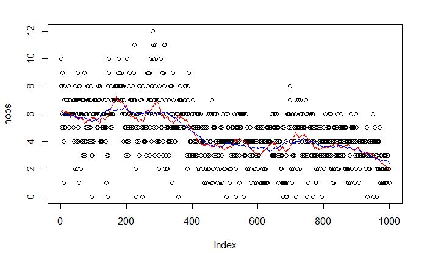

```r
plotNobs(toa1335_rbi_yaps)
```

### Get inp and run YAPS

```r
ping_type <- 'rbi'
inp1335_rbi <- getInp(toa=toa1335_rbi_yaps, hydros=hydros_yaps, E_dist="t", n_ss=5, pingType=ping_type, rbi_min=rbi_min, rbi_max=rbi_max, sdInits=1, ss_data_what="est", ss_data=0, biTable=NULL)
inp1335_rbi$inits[1] <- rnorm(1, 1, 1)
yaps1335_rbi <- runYaps(inp1335_rbi, maxIter=500, getPlsd=TRUE, getRep=TRUE, silent=TRUE)
```

```
[1] "Running yaps..."
[1] "...yaps converged (obj: -11229.6141450874)"
```